# Plantilla dades longitudinals

- 1 Introducció
- 2 Anàlisi longitudinal
  - 2.1 tas
  - 2.2 tad
  - 2.3 Segons el grup
    - 2.3.1 tas
      - 2.3.1.1 sexo
      - 2.3.1.2 grupo
    - 2.3.2 tad
      - 2.3.2.1 sexo
      - 2.3.2.2 grupo

VHIR-UEB-for-019v.01

# 1 Introducció

Aquesta plantilla mostra un exemple d’anàlisi longitudinal, metodologia que s’utilitza quan volem analitzar dades amb mesures repetides, és a dir, dades d’una mateixa variable en diferents moments temporals. L’objectiu principal d’aquesta anàlisi és conèixer si són significatius tant els canvis individuals com els canvis entre individus, així com identificar si hi ha variables (covariables) que influeixen en aquests canvis.

Per a dur a terme aquesta anàlisi, els models lineals mixtes són la principal eina estadística. Aquests models estimen els valors esperats de les observacions, coneguts com a efectes fixos, i també les variàncies i covariàncies, conegudes com a efectes aleatoris.

Els models lineals mixtes permeten identificar canvis en les variables al llarg del temps, poden ser univariants, que analitzen una sola variable, o multivariants, que analitzen múltiples variables simultàniament, i poden gestionar dades desbalancejades o incompletes, que són freqüents en estudis amb mesures repetides.

Abans de començar amb aquesta anàlisi en programari R, es recomana consultar la plantilla de descriptius on estan explicats els passos previs de qualsevol anàlisi. A continuació, ja es pot procedir a l’anàlisi comparativa.

En aquest exemple utilitzarem la base de dades **hta (Hipertensió arterial)**.

Tots els anàlisis han estat realitzats amb el programa estadístic “R”( R version 4.4.2 (2024-10-31 ucrt), Copyright (C) 2015 The R Foundation for Statistical Computing ).

# 2 Anàlisi longitudinal

```r
> ##################
> #### GRUPS DE VARIABLES
> ##################
>
> var_tas <- grep("tas", names(dat), value = T) # variables que contenen "tas" al nom
> var_tad <- grep("tad", names(dat), value = T) # variables que contenen "tad" al nom
> var_names <- names(dat) # nom de totes les variables
> var_group <- c("sexo", "grupo") # variables grupo
> var_select <- c("sexo", "grupo","tas1","tad1") # variables seleccionadas
> var_long <- c("tas","tad") # Variables longitudinales a analizar
> var_id <- "id" # Identificador del subjecte
> var_event = "Tiempo" # Temps de seguiment ( factor)
>
> ##################
```

En aquest apartat s’ha fet un seguiment de l’evolució de les diferents variables de seguiment, el que volem veure és si hi ha diferències en les variables tas, tad segons el moment temporal tenint en compte que les diferents mesures estan efectuades en el mateix pacient.

Per a cadascuna de les variables en format long s’ha realitzat un gràfic i ajustat el corresponent model:

- El **gràfic** mostra per a cada pacient (cada línia) l’evolució de tas, tad en els diferents punts temporals. La línia gruixuda mostra el valor mitjà.

La funció `ggplot()` del paquet *ggplot2* permet fer aquest tipus de gràfic, creant per a cada id una linea amb `geom_line()` i una per a la mitjana de tots els id amb `stat_summary()`.

El gràfic ens ajuda a veure si hi ha canvis, però per assegurar-nos que els canvis que veiem són significatius ho comprovem amb el model.

- El **model** ajusta les variables de seguiment tenint en compte que estan efectuades en un mateix instant/subjecte (id) i que es tenen diversos mesuraments en cada pacient. Els efectes aleatoris contemplen la variabilitat individual de cada cas.

La funció `lme()` del paquet *nlme* permet ajustar models lineals amb efectes mixtos. Aquesta funció segueix la següent estructura:

```r
> lme(fixed, data, random, correlation, weights, subset, method, na.action, control, contrasts = NULL, keep.data = TRUE)
```

Els principals arguments són:

- `fixed`: fórmula que descriu els efectes fixos del model, `y ~ 1 + x1 + x2`, amb la variable resposta a l’esquerre, i les variables explicatives a la dreta.
- `data`: *data frame* on estan les variables a analitzar.
- `random`: fórmula que descriu els efectes aleatoris del model, `~ 1 | group`, si volem que l’intercept sigui aleatori, o `~ 1 + x1 | group`, si volem que el pendent també sigui aleatòria.
- `method`: si volem les estimacions maximitzant la versemblança posem “ML”, i si volem maximitzar la verosimilitud restringida posem “REML”, per defecte la funció utilitza “REML”, ja que aquest pot produir estimacions no esbiaixades de paràmetres de variància i covariància.
- `control`: llista de valors control per a l’algorisme d’estimació, aquesta llista l’obtenim amb la funció `lmeControl()` del paquet *nlme*.

A partir del gràfic es decideixen quins models es realitzaran, i amb la funció `anova()` del paquet *stats*, que testa els models entre si en l’ordre especificat, sabrem quin dels models és millor.

Testant dos models, si el *pvalor* és menor a 0.05, ens quedem amb el segon model, sinó ens quedem amb el primer model.

La taula resultant del model final inclou els predictors, les estimacions, els intervals de confiança de les estimacions, els pvalors, el nombre d’individus analitzats i quantes observacions hi ha.

Els predictors en aquest tipus de models són l’intercept, que representa la variable a analitzar en el primer temps, i les següents files són els diferents temps excepte el primer que és el de referència.

```r
> library(sjPlot)
> library(sjmisc)
> library(sjlabelled)
>
> pl <- list()
>
> sample_dat_l <- dat_long %>% filter(Tiempo %in% c("1","2","3","4"))
>
> for (i in seq_along(var_long)) {
+   cat(" \n##", var_long[i], " \n")
+
+   ### GRAFIC
+   print(ggplot(sample_dat_l, aes_string(x = var_event, y = var_long[i])) +
+           geom_line(aes_string(group = var_id), alpha = 0.5) +
+           stat_summary(aes(group = 1), geom = "line", fun.y = mean, size = 3) +
+           theme_bw() +
+           labs( title = paste("Evolución global", var_long[i]),
+                 x = NULL,   y = var_long[i],    color = NULL))
+
+   cat("\n")
+   ### MODEL
+
+   ctrl <- lmeControl(opt = 'optim')
+   frml <- as.formula(paste0(var_long[i], "~", var_event))
+
+   ### REVISAR AMB CALMA EFECTES ALEATORIS EN CADA ESTUDI ###
+   model1 <- lme(frml, random = ~ 1 | id, data = sample_dat_l,
+                 method = "REML", control = ctrl)
+
+   model2 <- lme(frml, random = ~ Tiempo | id, data = sample_dat_l,
+                 method = "REML", control = ctrl)
+
+   if (na.omit(anova(model1, model2)$"p-value") < 0.05) {
+     model <- model2
+   } else {
+     model <- model1
+   }
+
+
+   cat(tab_model(model)$knitr,"\n--------\n")
+   cat("\n")
+   print(plot_model(model,colors = "#8d35cc",show.values = T) )
+   cat("\n")
+ }
```

## 2.1 tas

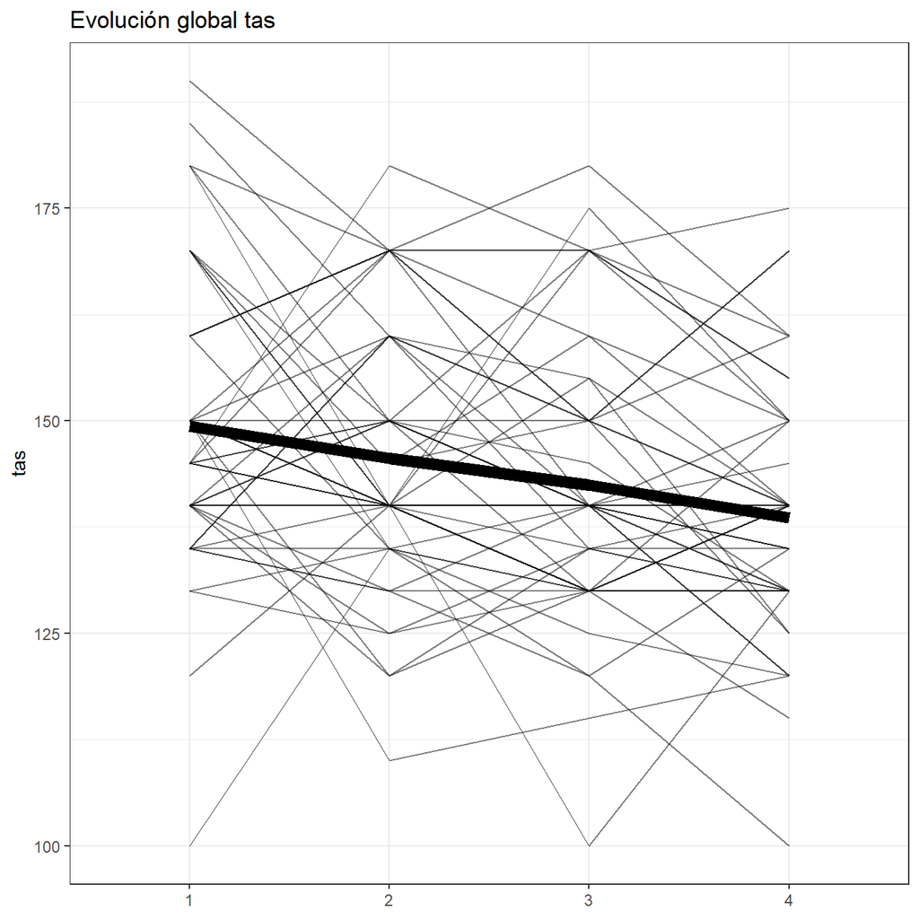

|  | tas |  |  |
| --- | --- | --- | --- |
| Predictors | Estimates | CI | p |
| (Intercept) | 149.39 | 144.83 – 153.95 | **<0.001** |
| Tiempo [2] | -3.78 | -8.27 – 0.72 | 0.099 |
| Tiempo [3] | -6.94 | -11.44 – -2.44 | **0.003** |
| Tiempo [4] | -10.82 | -15.31 – -6.32 | **<0.001** |
| N <sub>id</sub> | 49 |  |  |
| Observations | 196 |  |  |

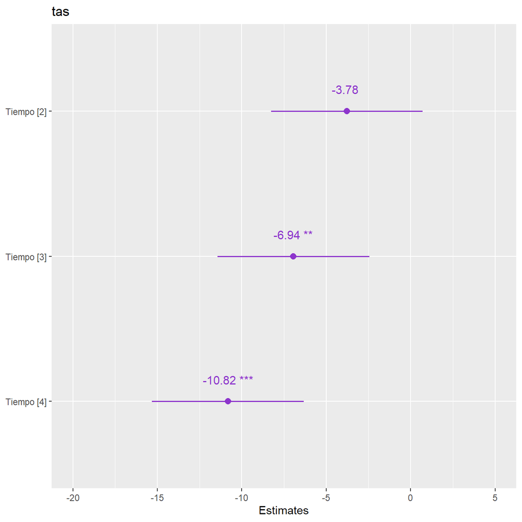

## 2.2 tad

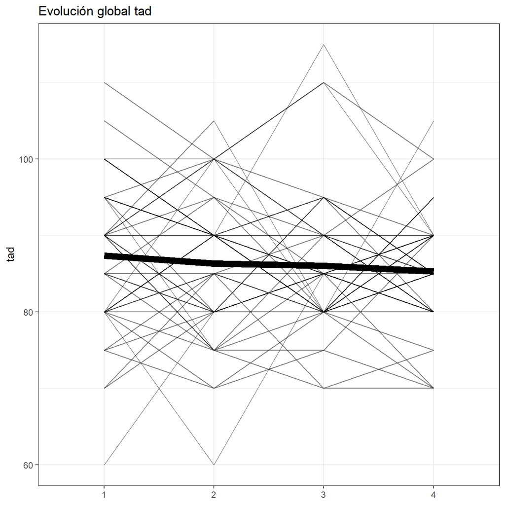

|  | tad |  |  |
| --- | --- | --- | --- |
| Predictors | Estimates | CI | p |
| (Intercept) | 87.35 | 84.80 – 89.89 | **<0.001** |
| Tiempo [2] | -1.02 | -3.88 – 1.84 | 0.482 |
| Tiempo [3] | -1.33 | -4.19 – 1.53 | 0.361 |
| Tiempo [4] | -2.04 | -4.90 – 0.82 | 0.161 |
| N <sub>id</sub> | 49 |  |  |
| Observations | 196 |  |  |

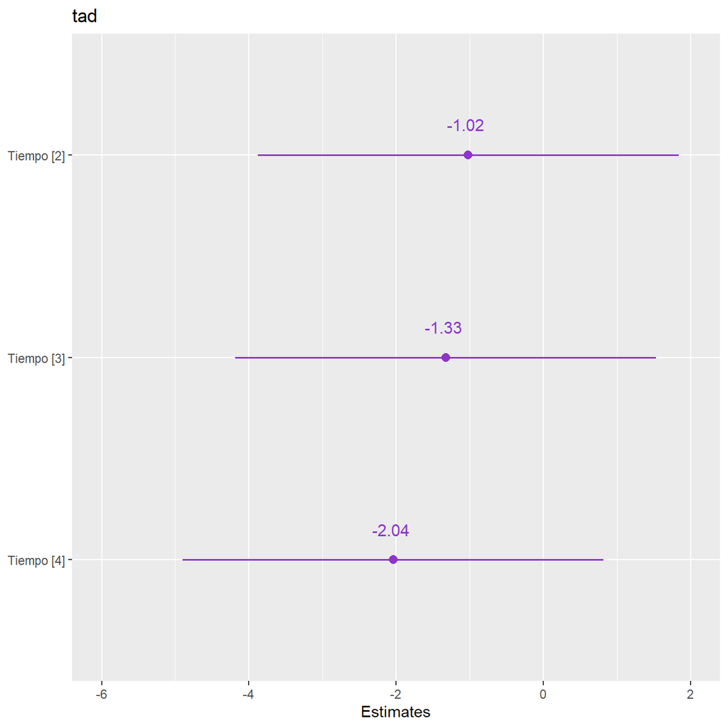

En aquest exemple a partir dels gràfics de tas i tad decidim realitzar dos models, un amb l’intercept com a efecte aleatori, i l’altre amb l’intercept i la pendent com a efectes aleatoris, ja que veiem que cada id comença en un punt diferent, i les pendents semblen variar. L’intercept es representa com un 1, i la pendent en aquest cas és la variable Tiempo.

En el model de tas veiem que les estimacions a mesura que avança el temps van disminuint, és a dir, entre el temps 2 i 1 el valor de tas és quasi 4 unitats menor, entre el temps 3 i 1 és quasi 7 unitats menor, i entre el temps 4 i 1 és quasi 11 unitats menor. D’aquestes estimacions són significatives la de l’intercept, per tant, afirmem que a temps 1 els valors de tas són diferents entre els individus, i la dels temps 3 i 4, per tant, afirmem que hi ha diferències significatives respecte al temps 1.

En canvi, en el model de tad, les estimacions també van disminuint a mesura que passa el temps, però només és significativa la de l’intercept, per tant, no podem afirmar que hi hagi diferències en el valor de tad respecte al temps 1.

A vegades hi ha variables confusores que afecten aquests resultats, per a comprovar-ho es realitzen els mateixos models però afegint una o varies variable grup.

## 2.3 Segons el grup

En aquest apartat s’ha avaluat l’evolució de les variables de seguiment segons el grup. Per a cadascun dels paràmetres s’ha realitzat un gràfic i ajustat un model mixt per a mesures repetides tenint en compte que les diferents mesures estan efectuades en el mateix pacient.

- El gràfic mostra per a cada pacient (cada línia) l’evolució dels marcadors en els diferents punts temporals. Les línies gruixudes mostren el valor mitjà per a cadascun dels grups.
- La taula mostra el resultat del model. En aquest model s’ajusta la variable d’interès en funció del grup tenint en compte que estan efectuades en un mateix instant/subjecte i que es tenen diversos mesuraments en cada pacient. Els efectes aleatoris contemplen la variabilitat individual de cada cas.

En el cas que el pvalor de la variable grup sigui significatiu, podem fer un model amb interacció.

```r
> pl <- list()
> for (i in seq_along(var_long)) {
+   cat(" \n###", var_long[i], " \n")
+  for (j in seq_along(var_group)) {
+   cat(" \n####", var_group[j], " \n")
+
+   gd <- sample_dat_l %>%
+     select(contains(var_id), contains(var_event),
+            grep(var_long[i],names(.), value = T), contains(var_group[j])) %>%
+     na.omit() %>%
+     group_by_at(vars(var_group[j],var_event)) %>%
+     dplyr::summarise(value = mean(.data[[var_long[i]]],na.rm = T))
+   names(gd)[names(gd) == "value"] <- var_long[i]
+
+   pl <-
+     ggplot(sample_dat_l, aes_string(x = var_event, y = var_long[i],
+                                 color = var_group[j], group = var_group[j])) +
+     geom_line(aes_string(group = var_id), alpha = 0.5) +
+     geom_line(data = gd, alpha = .8, size = 3) +
+     theme_bw() +
+     labs(title = paste("Evolución", var_long[i],"segun", var_group[j]),
+          x = NULL,
+          y = var_long[i],
+          color = NULL)
+   print(pl)
+   # print( htmltools::renderTags(as.widget(ggplotly(pl[[var_long[i]]])))$html)
+
+   ctrl <- lmeControl(opt = 'optim')
+   frml <- as.formula(paste0(var_long[i], "~", var_event, "+",var_group[j]))
+   dd_long <- sample_dat_l %>% select(contains(var_long[i]),
+                                  contains(var_group[j]),
+                                  contains(var_event),
+                                  contains(var_id)) %>% na.omit()
+
+
+   ### REVISAR AMB CALMA EFECTES ALEATORIS EN CADA ESTUDI
+   model1 <- lme(frml, random = ~1| id, data = dd_long, method = "REML",
+                control = ctrl)
+   model2 <- lme(frml, random = ~ Tiempo| id, data = dd_long, method = "REML", control = ctrl)
+
+   if (na.omit(anova(model1, model2)$"p-value") < 0.05) {
+     model <- model2
+   } else {
+     model <- model1
+   }
+
+
+
+   cat(tab_model(model,show.df = F)$knitr,"\n--------\n")
+   cat("\n")
+   print(plot_model(model,colors = "#8d35cc",show.values = T) )
+   cat("\n")
+
+   ### AMB INTERACCIÓ en el cas que la variable grup sigui significativa
+   #cat(" \n#####", "Interacció ",var_event, " x ", var_group[j], " \n")
+   #frml2 <- as.formula(paste0(var_long[i], "~", var_event, "+",var_group[j], "+", var_event, "*", var_group[j]))
+
+   ### REVISAR AMB CALMA EFECTES ALEATORIS EN CADA ESTUDI
+   #model1 <- lme(frml2, random = ~1| id, data = dd_long, method = "REML", control = ctrl)
+   #model2 <- lme(frml2, random = ~ Tiempo| id, data = dat_long, method = "REML", control = ctrl)
+
+   #if (na.omit(anova(model1, model2)$"p-value") < 0.05) {
+     #model <- model2
+   #} else {
+     #model <- model1
+   #}
+
+
+
+   #cat(tab_model(model,show.df = F)$knitr,"\n--------\n")
+   #cat("\n")
+   #print(plot_model(model,colors = "#8d35cc",show.values = T) )
+   #cat("\n")
+ }
+ }
```

### 2.3.1 tas

#### 2.3.1.1 sexo

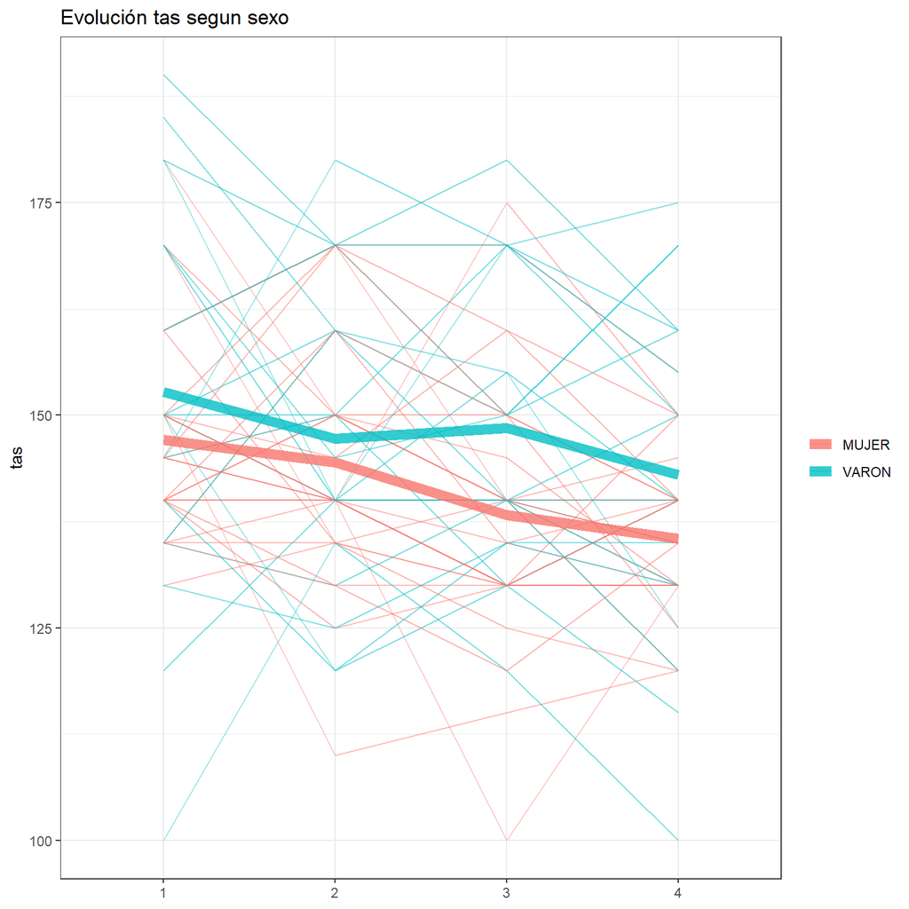

|  | tas |  |  |
| --- | --- | --- | --- |
| Predictors | Estimates | CI | p |
| (Intercept) | 146.72 | 141.34 – 152.10 | **<0.001** |
| Tiempo [2] | -3.78 | -8.27 – 0.72 | 0.099 |
| Tiempo [3] | -6.94 | -11.44 – -2.44 | **0.003** |
| Tiempo [4] | -10.82 | -15.31 – -6.32 | **<0.001** |
| sexo [VARON] | 6.54 | -0.82 – 13.90 | 0.080 |
| N <sub>id</sub> | 49 |  |  |
| Observations | 196 |  |  |

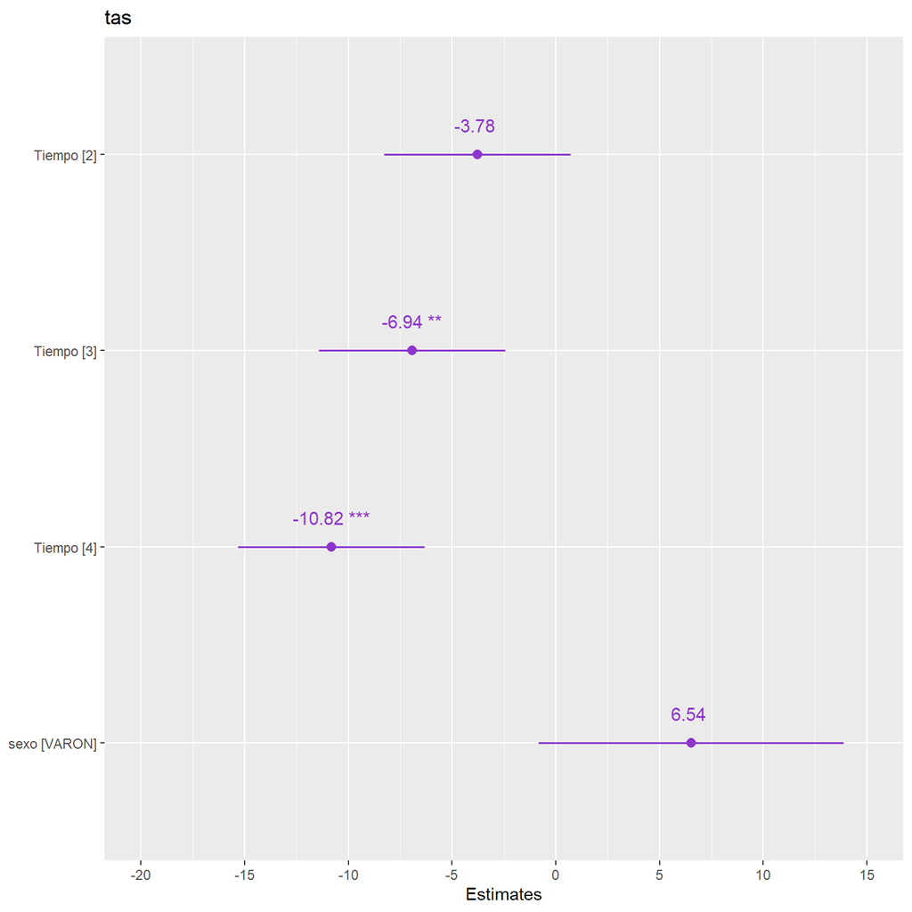

#### 2.3.1.2 grupo

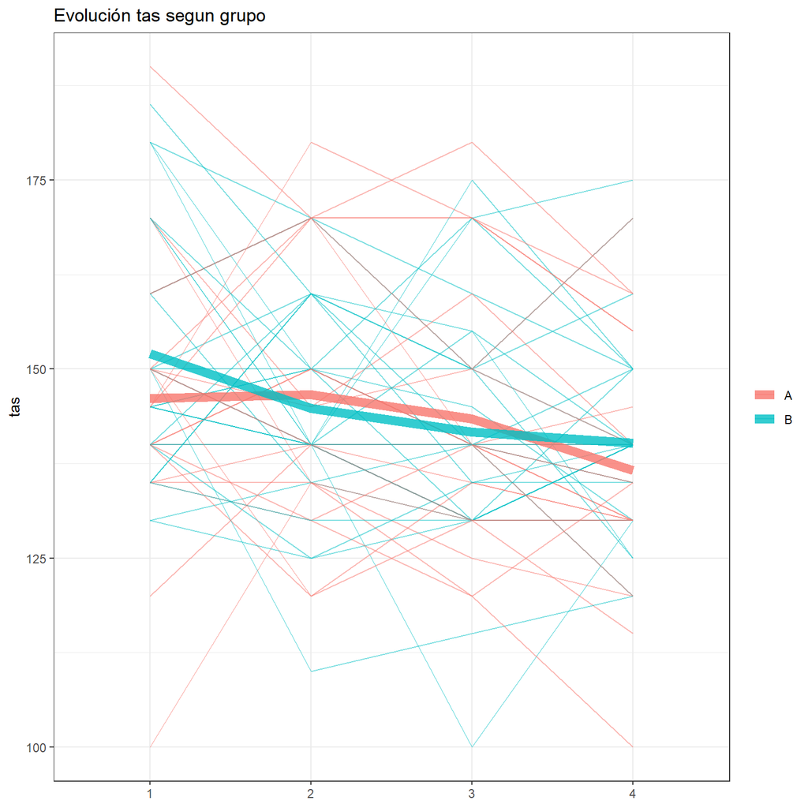

|  | tas |  |  |
| --- | --- | --- | --- |
| Predictors | Estimates | CI | p |
| (Intercept) | 148.56 | 142.44 – 154.69 | **<0.001** |
| Tiempo [2] | -3.78 | -8.27 – 0.72 | 0.099 |
| Tiempo [3] | -6.94 | -11.44 – -2.44 | **0.003** |
| Tiempo [4] | -10.82 | -15.31 – -6.32 | **<0.001** |
| grupo [B] | 1.49 | -6.01 – 9.00 | 0.691 |
| N <sub>id</sub> | 49 |  |  |
| Observations | 196 |  |  |

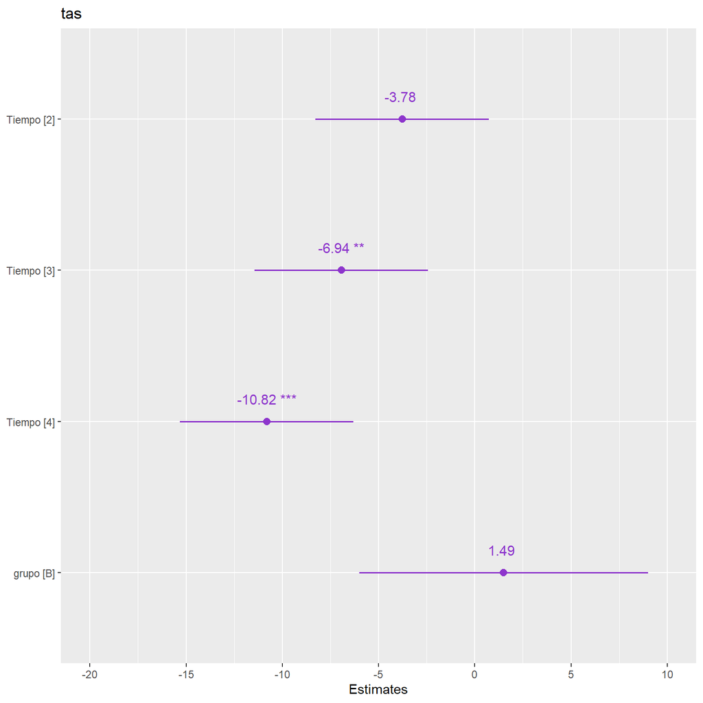

### 2.3.2 tad

#### 2.3.2.1 sexo

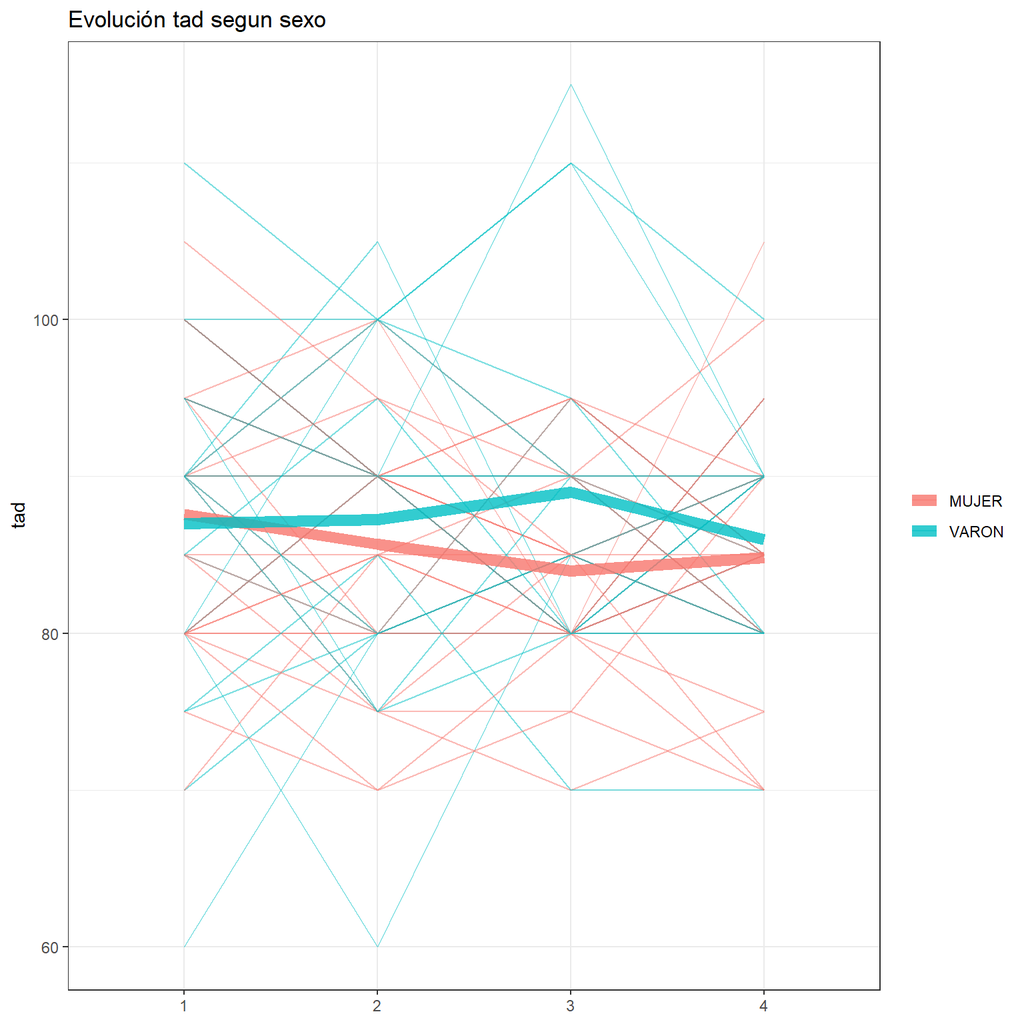

|  | tad |  |  |
| --- | --- | --- | --- |
| Predictors | Estimates | CI | p |
| (Intercept) | 86.61 | 83.64 – 89.58 | **<0.001** |
| Tiempo [2] | -1.02 | -3.88 – 1.84 | 0.482 |
| Tiempo [3] | -1.33 | -4.19 – 1.53 | 0.361 |
| Tiempo [4] | -2.04 | -4.90 – 0.82 | 0.161 |
| sexo [VARON] | 1.80 | -2.02 – 5.61 | 0.349 |
| N <sub>id</sub> | 49 |  |  |
| Observations | 196 |  |  |

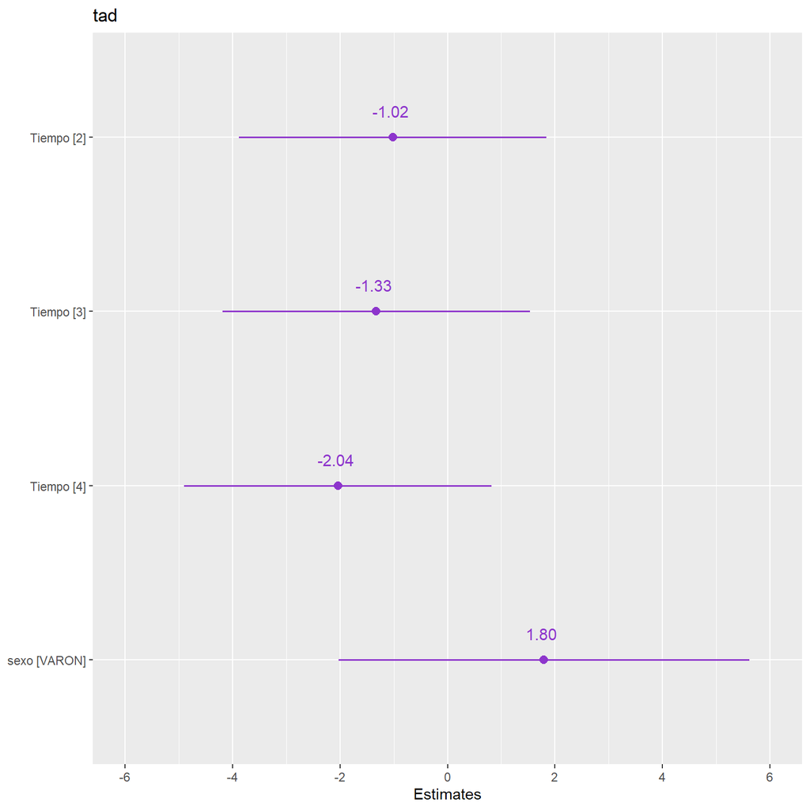

#### 2.3.2.2 grupo

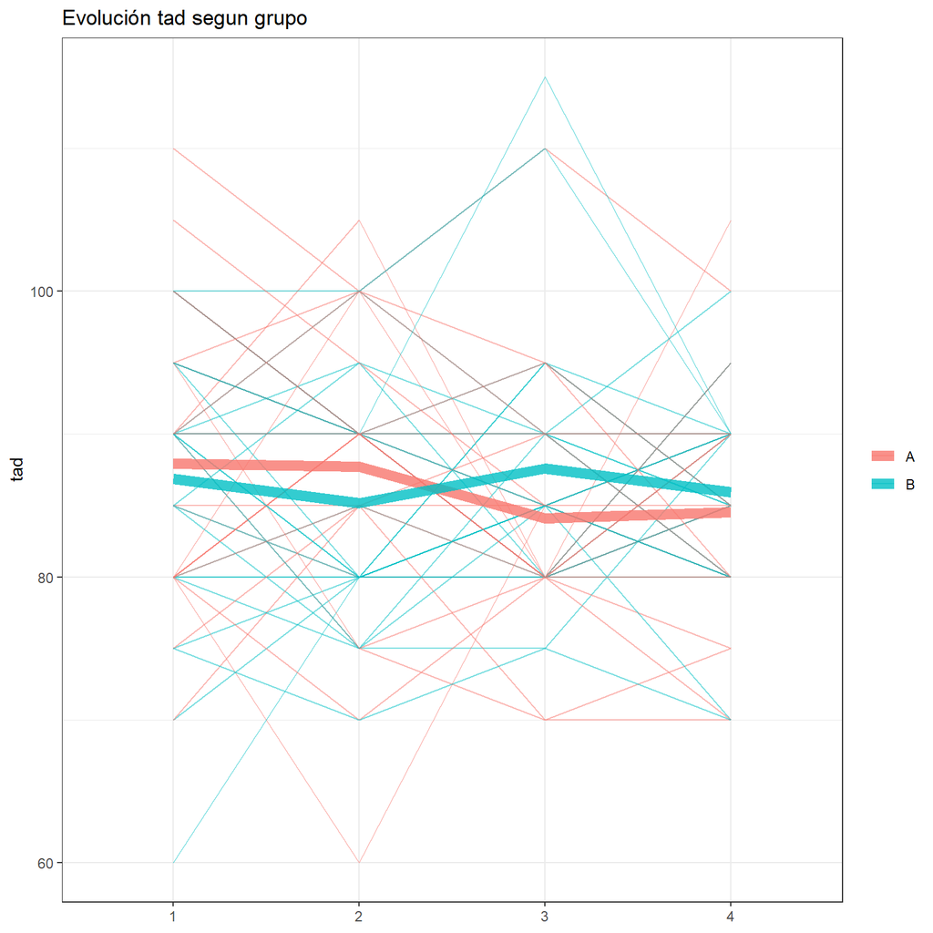

|  | tad |  |  |
| --- | --- | --- | --- |
| Predictors | Estimates | CI | p |
| (Intercept) | 87.18 | 83.89 – 90.46 | **<0.001** |
| Tiempo [2] | -1.02 | -3.88 – 1.84 | 0.482 |
| Tiempo [3] | -1.33 | -4.19 – 1.53 | 0.361 |
| Tiempo [4] | -2.04 | -4.90 – 0.82 | 0.161 |
| grupo [B] | 0.31 | -3.50 – 4.12 | 0.871 |
| N <sub>id</sub> | 49 |  |  |
| Observations | 196 |  |  |

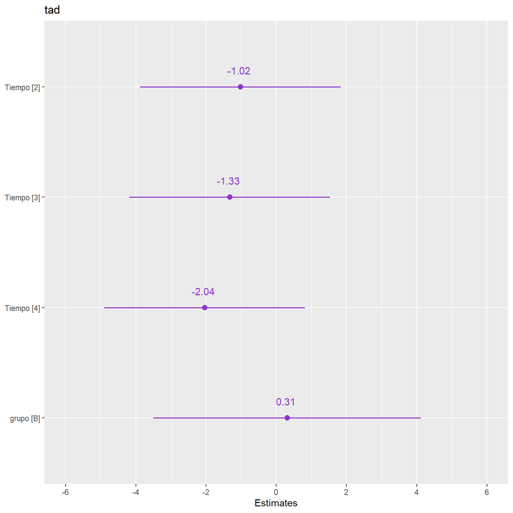

Del model de tas amb sexo, podríem dir que el valor de tas en VARON amb temps fix és aproximadament 6.5 unitats major que el valor de tas en MUJER amb temps fix, però aquesta diferència no és significativa, i del model de tas amb grupo, podríem dir que el valor de tas en B amb temps fix és aproximadament 1.5 unitats major que el valor de tas en A amb temps fix, però com abans, aquesta diferència no és significativa.

Per als models tad amb sexo i tad amb grupo obtenim que en ambdós models tampoc són significatives les diferències.

Com no són significatives les diferències, en cap cas realitzem interaccions.